# Bài Tập Thực hành

Nguyen Thanh Truc (23C23012)

28-05-2024

```r
knitr::opts_knit$set(root.dir = "/Users/fennytruc/Desktop/Statistics/CoNgoc_MHHTK/")
library(tidyverse)
library(ggplot2)
library(dplyr)
library(caret)
library(car)
library(MASS) # stepAIC
```

```r
oto <- read.csv("./datasets-20240504/auto-mpg_data.csv", sep = "", header = FALSE)
names(oto) <- c("mpg", "cylinders", "displacement", "horsepower", "weight", "acceleration", "modelyear", "origin", "carname")
head(oto)
```

|  | mpg | cylinders | displacement | horsepower | weight | acceleration | modelyear | origin | carname |
| --- | --- | --- | --- | --- | --- | --- | --- | --- | --- |
| 1 | 18 | 8 | 307 | 130.0 | 3504 | 12.0 | 70 | 1 | chevrolet chevelle malibu |
| 2 | 15 | 8 | 350 | 165.0 | 3693 | 11.5 | 70 | 1 | buick skylark 320 |
| 3 | 18 | 8 | 318 | 150.0 | 3436 | 11.0 | 70 | 1 | plymouth satellite |
| 4 | 16 | 8 | 304 | 150.0 | 3433 | 12.0 | 70 | 1 | amc rebel sst |
| 5 | 17 | 8 | 302 | 140.0 | 3449 | 10.5 | 70 | 1 | ford torino |
| 6 | 15 | 8 | 429 | 198.0 | 4341 | 10.0 | 70 | 1 | ford galaxie 500 |

```r
str(oto)
```

```
## 'data.frame':    398 obs. of  9 variables:
##  $ mpg         : num  18 15 18 16 17 15 14 14 14 15 ...
##  $ cylinders   : int  8 8 8 8 8 8 8 8 8 8 ...
##  $ displacement: num  307 350 318 304 302 429 454 440 455 390 ...
##  $ horsepower  : chr  "130.0" "165.0" "150.0" "150.0" ...
##  $ weight      : num  3504 3693 3436 3433 3449 ...
##  $ acceleration: num  12 11.5 11 12 10.5 10 9 8.5 10 8.5 ...
##  $ modelyear   : int  70 70 70 70 70 70 70 70 70 70 ...
##  $ origin      : int  1 1 1 1 1 1 1 1 1 1 ...
##  $ carname     : chr  "chevrolet chevelle malibu" "buick skylark 320" "plymouth satellite" "amc rebel sst" ...
```

```r
data <- oto[,-9]
data[,"horsepower"] <- as.numeric(data[,"horsepower"])
data[,"cylinders"] <- as.factor(data[,"cylinders"])
data[,"modelyear"] <- as.factor(data[,"modelyear"])
data[,"origin"] <- as.factor(data[,"origin"])
str(data)
```

```
## 'data.frame':    398 obs. of  8 variables:
##  $ mpg         : num  18 15 18 16 17 15 14 14 14 15 ...
##  $ cylinders   : Factor w/ 5 levels "3","4","5","6",..: 5 5 5 5 5 5 5 5 5 5 ...
##  $ displacement: num  307 350 318 304 302 429 454 440 455 390 ...
##  $ horsepower  : num  130 165 150 150 140 198 220 215 225 190 ...
##  $ weight      : num  3504 3693 3436 3433 3449 ...
##  $ acceleration: num  12 11.5 11 12 10.5 10 9 8.5 10 8.5 ...
##  $ modelyear   : Factor w/ 13 levels "70","71","72",..: 1 1 1 1 1 1 1 1 1 1 ...
##  $ origin      : Factor w/ 3 levels "1","2","3": 1 1 1 1 1 1 1 1 1 1 ...
```

```r
# Kiểm tra giá trị Missing Data
colSums(is.na(data))
```

```
##          mpg    cylinders displacement   horsepower       weight acceleration
##            0            0            0            6            0            0
##    modelyear       origin
##            0            0
```

```r
colSums(is.na(data))*100/nrow(data)
```

```
##          mpg    cylinders displacement   horsepower       weight acceleration
##     0.000000     0.000000     0.000000     1.507538     0.000000     0.000000
##    modelyear       origin
##     0.000000     0.000000
```

Ta nhận thấy, có $horsepower$ có 6 observation bị MISSING VALUES, ta sẽ xử lý bằng cách fill MEDIAN

```r
# Replace Missing Values by MEDIAN
median(data$horsepower, na.rm=TRUE)
```

```
## [1] 93.5
```

```r
data$horsepower[is.na(data$horsepower)] <- median(data$horsepower, na.rm=TRUE)

colSums(is.na(data))
```

```
##          mpg    cylinders displacement   horsepower       weight acceleration
##            0            0            0            0            0            0
##    modelyear       origin
##            0            0
```

Vẽ BOXPLOT để kiểm tra OUTLIERS

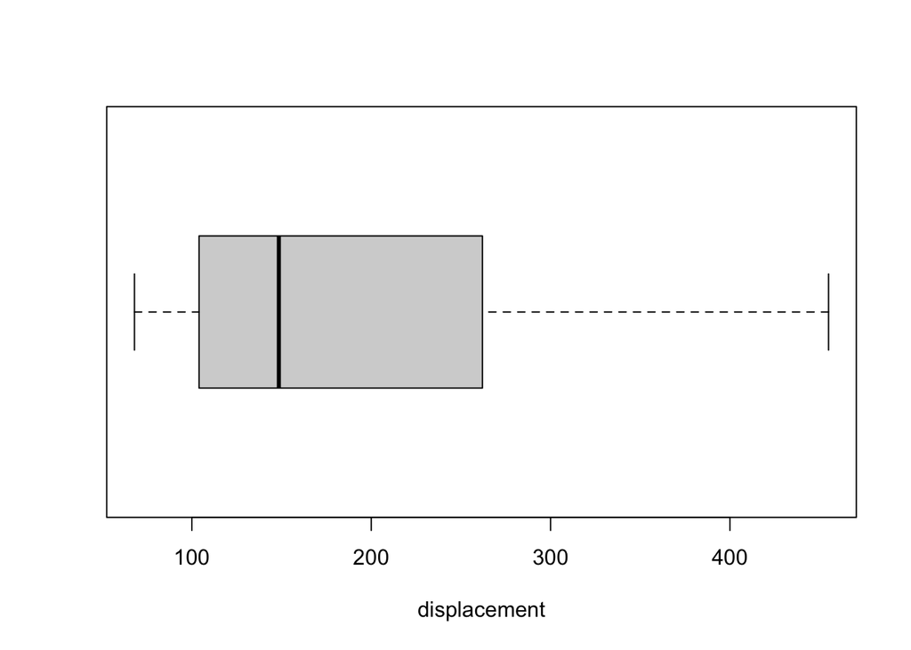

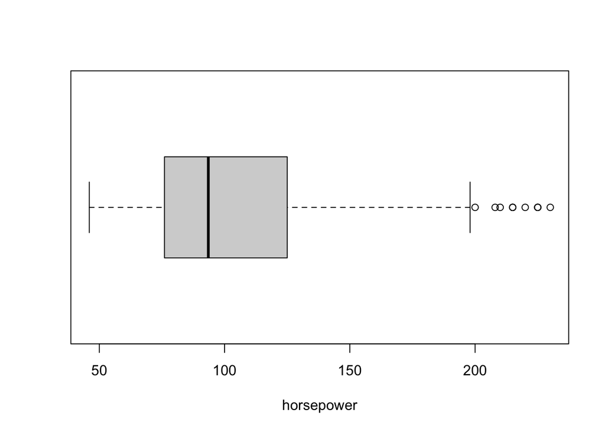

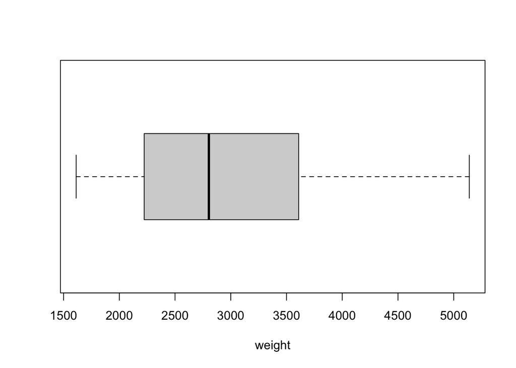

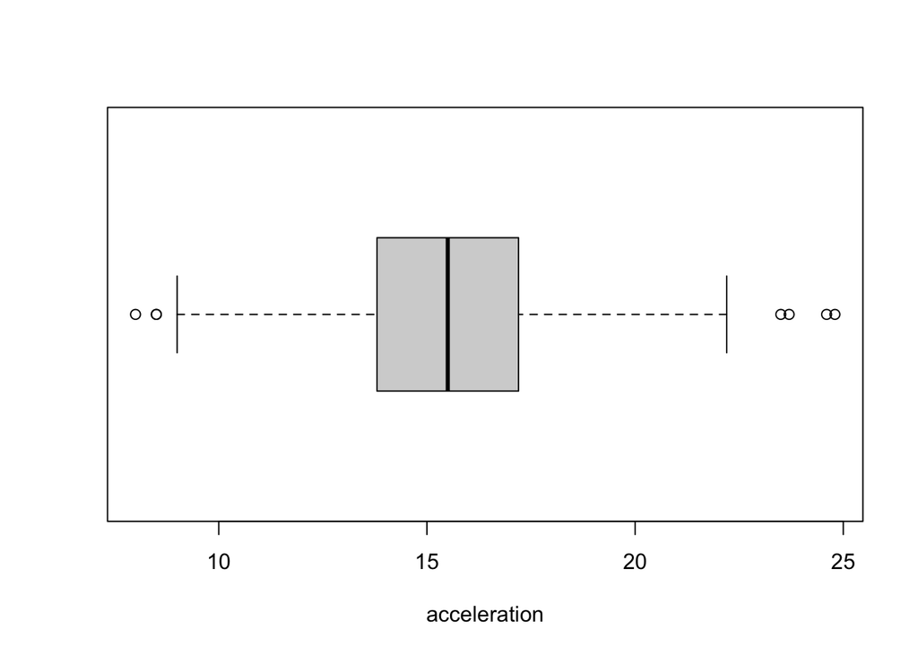

```r
for (col in c("displacement", "horsepower", "weight", "acceleration")) {
  boxplot(data[, col], xlab=col, horizontal = TRUE)
}
```

Từ kết quả Boxplot phía trên, ta nhận thấy có 2 biến $horsepower$ và $acceleration$ có OUTLIERS nên cần được xử lý

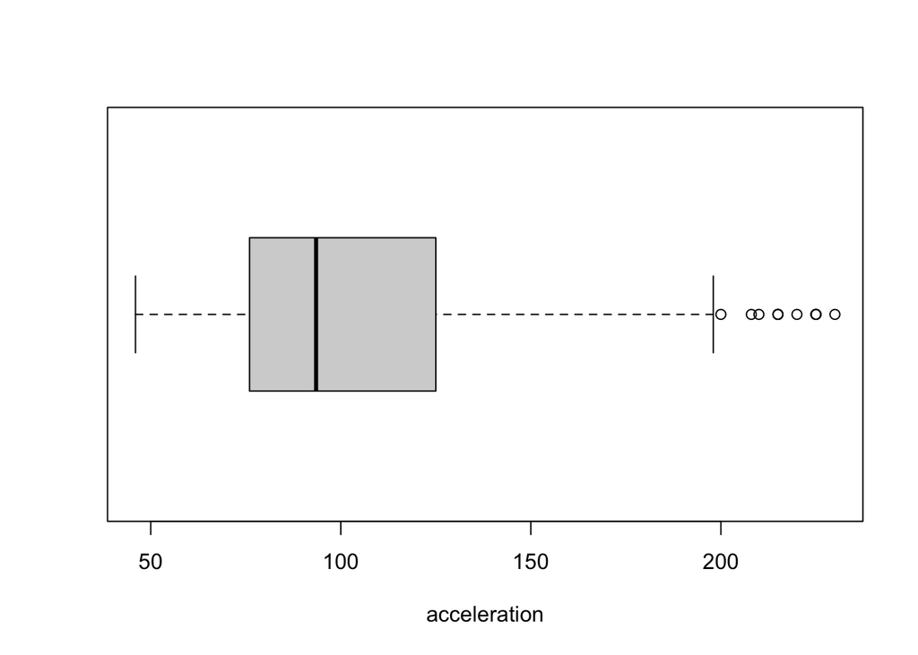

```r
# Plot boxplot để kiểm tra OUTLIERS
boxplot(data[, "horsepower"], xlab=col, horizontal = TRUE)
```

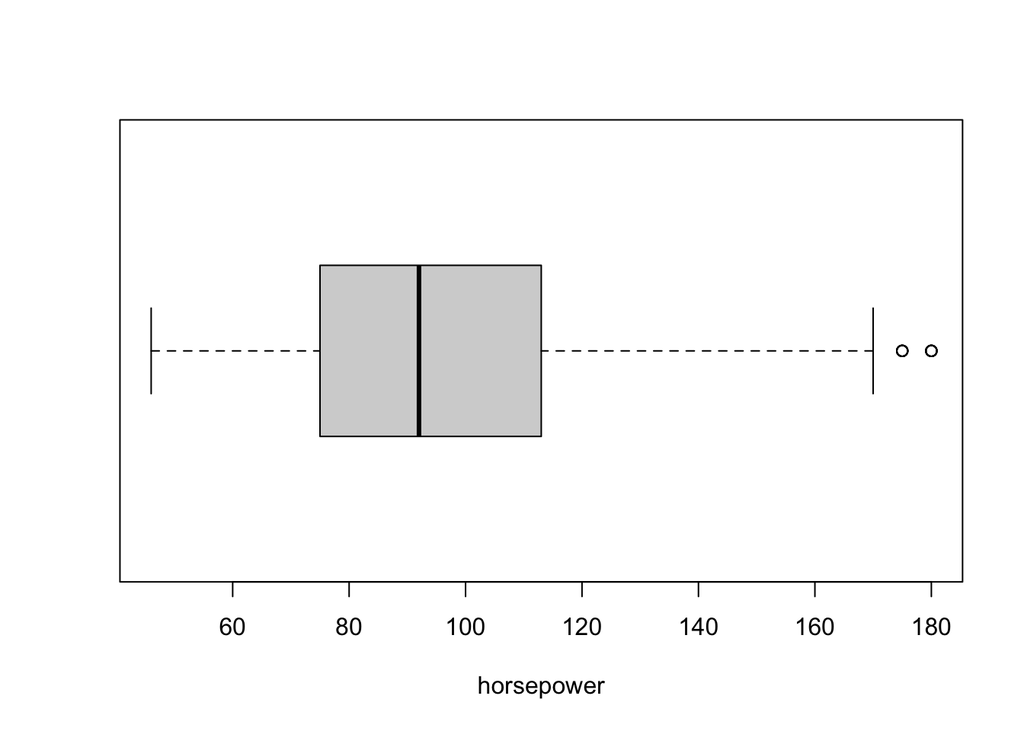

```r
# Remove OUTLIERS:
qf_horsepower <- quantile(data[, "horsepower"], .95)
data <- data %>% filter(horsepower <= qf_horsepower)

# Plot boxplot để kiểm tra OUTLIERS
boxplot(data[, "horsepower"], xlab="horsepower", horizontal = TRUE)
```

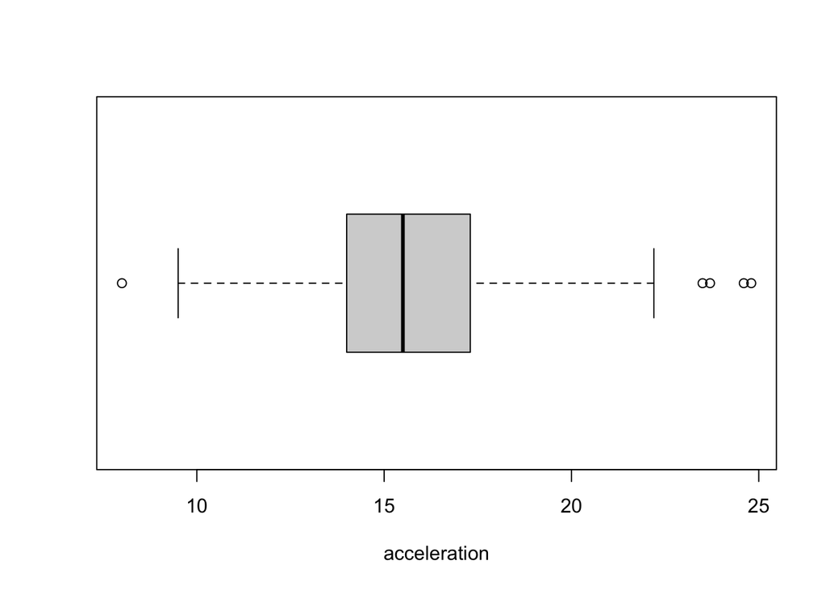

```r
# Plot boxplot để kiểm tra OUTLIERS
boxplot(data[, "acceleration"], xlab="acceleration", horizontal = TRUE)
```

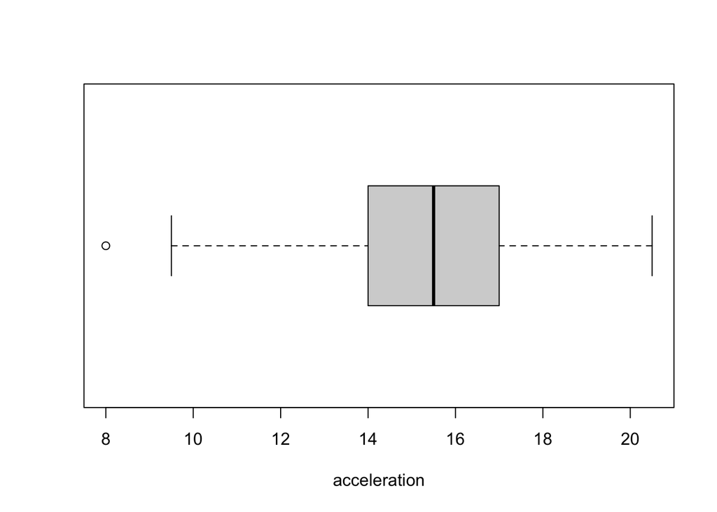

```r
# Remove OUTLIERS:
qf_acceleration <- quantile(data[, "acceleration"], .95)
data <- data %>% filter(acceleration <= qf_acceleration)

# Plot boxplot để kiểm tra OUTLIERS
boxplot(data[, "acceleration"], xlab="acceleration", horizontal = TRUE)
```

```r
nrow(data)
```

```
## [1] 364
```

Vậy observations đưa vào phân tích : 364 observations.

Kiểm tra hiện tượng Đa cụm tuyến:

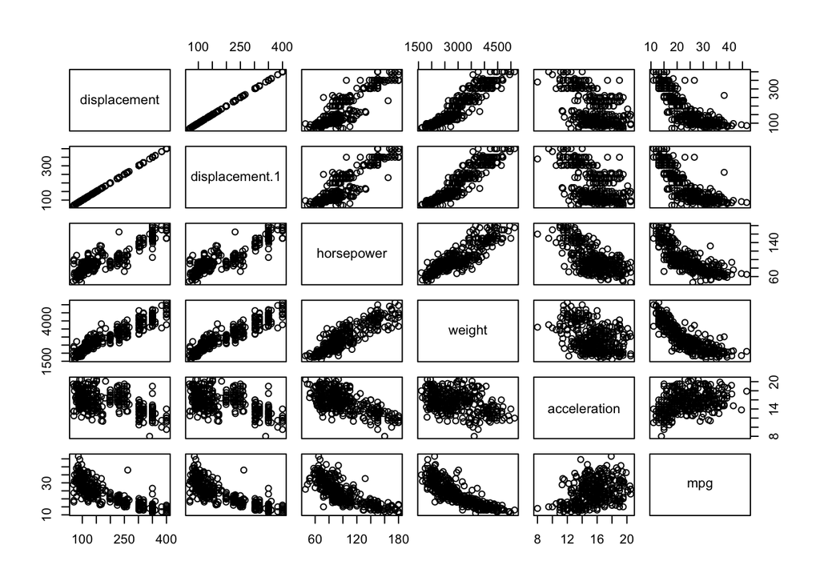

```r
plot(data[, c("displacement", "displacement", "horsepower", "weight", "acceleration", "mpg")])
```

```r
## Split the data into training and test set
set.seed(345)
n <- nrow(data)
# n = 27
training.samples <- data$mpg  %>%  createDataPartition(p = 0.8, list = FALSE)
train.data  <- data[training.samples, ]

test.data <- data[-training.samples, ]
dim(train.data)
```

```
## [1] 293   8
```

```r
dim(test.data)
```

```
## [1] 71  8
```

```r
head(train.data, 5)
```

|  | mpg | cylinders | displacement | horsepower | weight | acceleration | modelyear | origin |
| --- | --- | --- | --- | --- | --- | --- | --- | --- |
| 1 | 18 | 8 | 307 | 130 | 3504 | 12.0 | 70 | 1 |
| 2 | 15 | 8 | 350 | 165 | 3693 | 11.5 | 70 | 1 |
| 3 | 18 | 8 | 318 | 150 | 3436 | 11.0 | 70 | 1 |
| 5 | 17 | 8 | 302 | 140 | 3449 | 10.5 | 70 | 1 |
| 6 | 15 | 8 | 383 | 170 | 3563 | 10.0 | 70 | 1 |

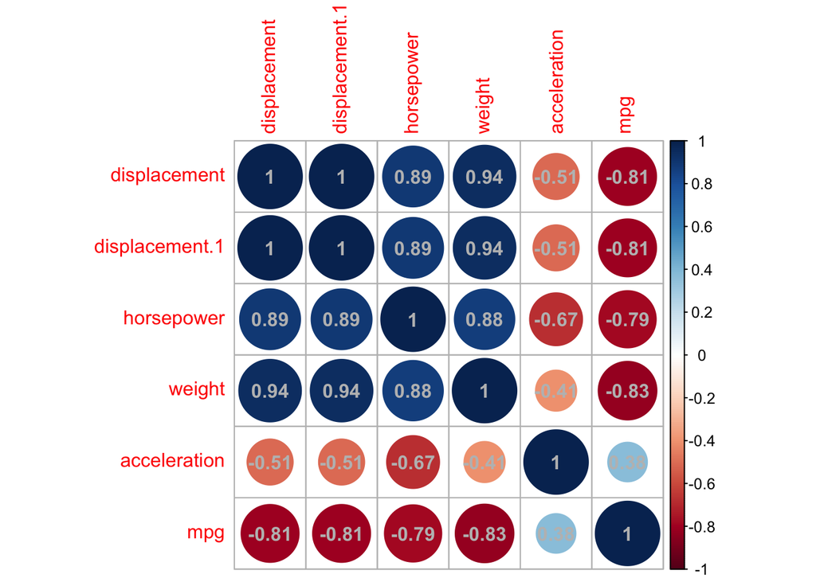

```r
numeric_cols <- c("displacement", "displacement", "horsepower", "weight", "acceleration", "mpg")
corrplot::corrplot(cor(train.data[, numeric_cols]), addCoef.col = "grey")
```

### MODEL WITH NUMERICAL COLUMNS

Ta sẽ dùng phương pháp VIF để loại bỏ hiện tượng đa cộng tuyến trong dữ liệu

**Step 1** Sử dụng hết tất cả các numerical columns để train $model 1$

```r
model_1 <- lm(mpg ~ displacement + horsepower + weight + acceleration, data = train.data)
summary(model_1)
```

```
##
## Call:
## lm(formula = mpg ~ displacement + horsepower + weight + acceleration,
##     data = train.data)
##
## Residuals:
##      Min       1Q   Median       3Q      Max
## -11.7778  -2.8323  -0.2163   2.2590  16.4337
##
## Coefficients:
##               Estimate Std. Error t value Pr(>|t|)
## (Intercept)  52.128748   3.270816  15.938  < 2e-16 ***
## displacement -0.013145   0.008231  -1.597  0.11134
## horsepower   -0.094512   0.023035  -4.103 5.32e-05 ***
## weight       -0.003467   0.001045  -3.319  0.00102 **
## acceleration -0.411931   0.167265  -2.463  0.01437 *
## ---
## Signif. codes:  0 '***' 0.001 '**' 0.01 '*' 0.05 '.' 0.1 ' ' 1
##
## Residual standard error: 4.089 on 288 degrees of freedom
## Multiple R-squared:  0.7072, Adjusted R-squared:  0.7031
## F-statistic: 173.9 on 4 and 288 DF,  p-value: < 2.2e-16
```

**Step** Sử dụng function $VIF$ để tìm chỉ ra biến có VIF cao $(>= 10)$ để loại bỏ hiện tượng đa cộng tuyến

```r
# Calculating VIF
vif_model_1 <- vif(model_1)
vif_model_1
```

```
## displacement   horsepower       weight acceleration
##    10.777583     9.249697    12.304220     2.585535
```

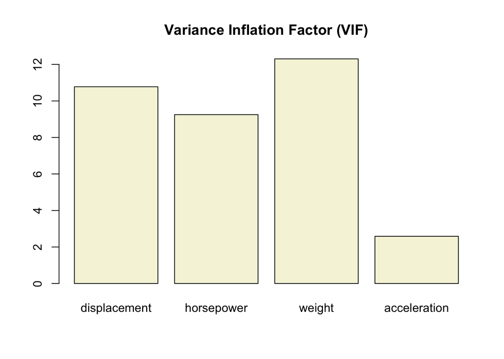

```r
# Visualizing VIF
barplot(vif_model_1, col = "beige", main = "Variance Inflation Factor (VIF)")
```

**Nhận xét** Từ bảng kết quả VIF ở trên, ta nhận thấy $VIF_{weight} = 12.3$ > 10 nên sẽ bị loại.

**Step 3** Ta sẽ chạy lại model mà data đã remove đi biến $weight$

```r
# After removing weight:
model_2 <- lm(mpg ~ displacement + horsepower + acceleration, data = train.data)
summary(model_2)
```

```
##
## Call:
## lm(formula = mpg ~ displacement + horsepower + acceleration,
##     data = train.data)
##
## Residuals:
##      Min       1Q   Median       3Q      Max
## -12.2627  -2.9079  -0.2147   2.2206  16.5707
##
## Coefficients:
##               Estimate Std. Error t value Pr(>|t|)
## (Intercept)  53.715765   3.291268  16.321  < 2e-16 ***
## displacement -0.032834   0.005804  -5.657 3.70e-08 ***
## horsepower   -0.132274   0.020374  -6.492 3.67e-10 ***
## acceleration -0.685192   0.148101  -4.627 5.62e-06 ***
## ---
## Signif. codes:  0 '***' 0.001 '**' 0.01 '*' 0.05 '.' 0.1 ' ' 1
##
## Residual standard error: 4.16 on 289 degrees of freedom
## Multiple R-squared:  0.696,  Adjusted R-squared:  0.6929
## F-statistic: 220.6 on 3 and 289 DF,  p-value: < 2.2e-16
```

```r
# Calculating VIF
vif_values_2 <- vif(model_2)
vif_values_2
```

```
## displacement   horsepower acceleration
##     5.179256     6.993219     1.959097
```

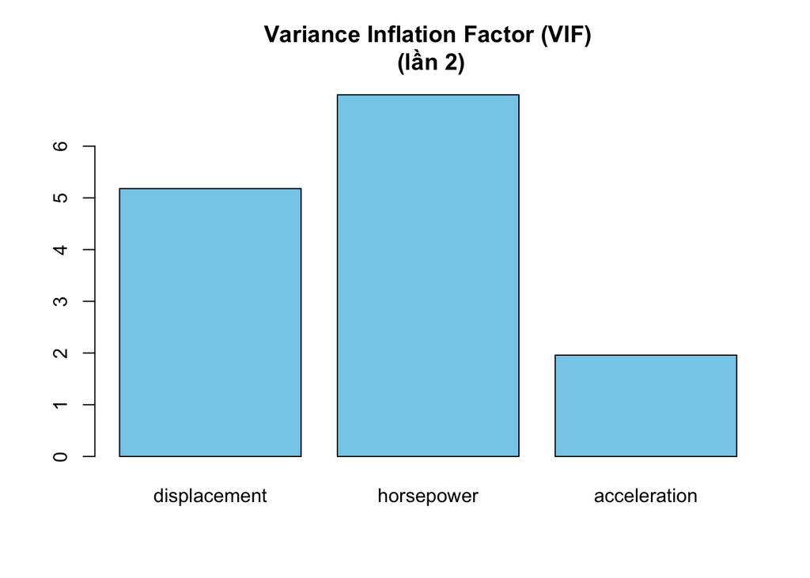

```r
# Visualizing VIF
barplot(vif_values_2, col = "skyblue", main = "Variance Inflation Factor (VIF)\n (lần 2)")
```

### FULL MODEL

```r
# Remove weight:
train.data <- train.data[, c("mpg", "cylinders", "displacement", "horsepower", "acceleration", "modelyear", "origin")]
# Build the model
full_model <- lm(mpg ~., data = train.data)
summary(full_model)
```

```
##
## Call:
## lm(formula = mpg ~ ., data = train.data)
##
## Residuals:
##     Min      1Q  Median      3Q     Max
## -7.3664 -1.8014 -0.1115  1.4792 13.2745
##
## Coefficients:
##               Estimate Std. Error t value Pr(>|t|)
## (Intercept)  38.081833   2.928288  13.005  < 2e-16 ***
## cylinders4    9.404020   1.606349   5.854 1.38e-08 ***
## cylinders5    9.603079   2.509042   3.827 0.000161 ***
## cylinders6    8.550966   1.897668   4.506 9.83e-06 ***
## cylinders8   12.612194   2.314196   5.450 1.13e-07 ***
## displacement -0.037399   0.008291  -4.511 9.63e-06 ***
## horsepower   -0.111771   0.016070  -6.955 2.63e-11 ***
## acceleration -0.526462   0.110635  -4.759 3.18e-06 ***
## modelyear71   0.559640   1.001182   0.559 0.576637
## modelyear72  -1.232234   1.038268  -1.187 0.236339
## modelyear73  -1.181122   0.967594  -1.221 0.223268
## modelyear74  -0.181810   1.012095  -0.180 0.857571
## modelyear75  -0.797428   1.024211  -0.779 0.436908
## modelyear76   0.789817   0.998694   0.791 0.429724
## modelyear77   1.816026   1.031556   1.760 0.079456 .
## modelyear78   1.606254   0.986457   1.628 0.104622
## modelyear79   3.763924   1.021617   3.684 0.000277 ***
## modelyear80   6.695430   1.058408   6.326 1.04e-09 ***
## modelyear81   4.983896   1.051431   4.740 3.45e-06 ***
## modelyear82   6.341645   1.045358   6.066 4.38e-09 ***
## origin2       0.094957   0.629941   0.151 0.880293
## origin3       1.723965   0.583996   2.952 0.003434 **
## ---
## Signif. codes:  0 '***' 0.001 '**' 0.01 '*' 0.05 '.' 0.1 ' ' 1
##
## Residual standard error: 2.924 on 271 degrees of freedom
## Multiple R-squared:  0.8592, Adjusted R-squared:  0.8483
## F-statistic: 78.75 on 21 and 271 DF,  p-value: < 2.2e-16
```

```r
anova(full_model)
```

|  | Df | Sum Sq | Mean Sq | F value | Pr(>F) |
| --- | --- | --- | --- | --- | --- |
| cylinders | 4 | 10350.10563 | 2587.526408 | 302.734346 | 1.169579e-98 |
| displacement | 1 | 996.71682 | 996.716816 | 116.613462 | 7.612938e-23 |
| horsepower | 1 | 495.82410 | 495.824104 | 58.010224 | 4.367504e-13 |
| acceleration | 1 | 302.17916 | 302.179155 | 35.354232 | 8.443172e-09 |
| modelyear | 12 | 1890.49499 | 157.541249 | 18.431946 | 6.236946e-29 |
| origin | 2 | 99.00402 | 49.502010 | 5.791616 | 3.443527e-03 |
| Residuals | 271 | 2316.28709 | 8.547185 | NA | NA |

Ta sử dung $step$ function như một cách tìm ra model rút gọn

```r
# MASS::stepAIC(full_model, trace=TRUE)
model_with_steps <- step(full_model, direction = "backward", trace = TRUE)
```

```
## Start:  AIC=649.79
## mpg ~ cylinders + displacement + horsepower + acceleration +
##     modelyear + origin
##
##                Df Sum of Sq    RSS    AIC
## <none>                      2316.3 649.79
## - origin        2     99.00 2415.3 658.05
## - displacement  1    173.91 2490.2 669.00
## - acceleration  1    193.54 2509.8 671.30
## - horsepower    1    413.50 2729.8 695.92
## - cylinders     4    566.17 2882.5 705.86
## - modelyear    12   1705.76 4022.0 787.48
```

```r
model_with_steps
```

```
##
## Call:
## lm(formula = mpg ~ cylinders + displacement + horsepower + acceleration +
##     modelyear + origin, data = train.data)
##
## Coefficients:
##  (Intercept)    cylinders4    cylinders5    cylinders6    cylinders8
##     38.08183       9.40402       9.60308       8.55097      12.61219
## displacement    horsepower  acceleration   modelyear71   modelyear72
##     -0.03740      -0.11177      -0.52646       0.55964      -1.23223
##  modelyear73   modelyear74   modelyear75   modelyear76   modelyear77
##     -1.18112      -0.18181      -0.79743       0.78982       1.81603
##  modelyear78   modelyear79   modelyear80   modelyear81   modelyear82
##      1.60625       3.76392       6.69543       4.98390       6.34164
##      origin2       origin3
##      0.09496       1.72397
```

## Kiểm định Fisher từng phần để chọn Mô hình tốt nhất

$$H_{0}: \text{Mô hình rút gọn} \\
H_1: \text{Mô hình đầy đủ}$$

```r
## Fisher partial test
anova(full_model, model_with_steps)
```

|  | Res.Df | RSS | Df | Sum of Sq | F | Pr(>F) |
| --- | --- | --- | --- | --- | --- | --- |
| 1 | 271 | 2316.287 | NA | NA | NA | NA |
| 2 | 271 | 2316.287 | 0 | 0 | NA | NA |

## Make Predictions

```r
# Make predictions
predictions <- model_with_steps %>% predict(test.data)
# Model performance
# (a) Prediction error, RMSE
RMSE(predictions, test.data$mpg)
```

```
## [1] 2.516516
```

```r
# (b) R-square
# R2(predictions, test.data$mpg)
```